# Statistical inference with the GSS data

## Setup

### Load packages

```r
library(ggplot2)
library(dplyr)
library(statsr)
```

### Load data

```r
load("gss.Rdata")
```

## Part 1: Data

### Population of Interest

The intention of the study is to track contemporary American society’s attitudes and behaviors through time. (http://gss.norc.org/About-The-GSS)

### Data Source

These data are from the General Social Survey (GSS) Cumulative file 1972-2012, but modified by removing missing values and creating factor variables or analysis in R. The sampling methods have changed over the years, complicating analysis (see below in Data Collection Methodology). The data are intended to test what people in the US think about a variety of topics and to trend these attitudes and behaviors through time. (http://gss.norc.org/About-The-GSS)

The original data set is from here:

Smith, Tom W., Michael Hout, and Peter V. Marsden. General Social Survey, 1972-2012 [Cumulative File]. ICPSR34802-v1. Storrs, CT: Roper Center for Public Opinion Research, University of Connecticut /Ann Arbor, MI: Inter-university Consortium for Political and Social Research [distributors], 2013-09-11. doi:10.3886/ICPSR34802.v1

Persistent URL: http://doi.org/10.3886/ICPSR34802.v1

### Data Collection Methodology

The following is a summary from http://gss.norc.org/documents/codebook/GSS_Codebook_AppendixA.pdf

Early data collection (1972-1974) was a modified probability sample. It sounds as if this is a clustered proportional semi-random sample where researchers canvassed an area and interviewed people face-to-face.

Later surveys also used the split transition design to test the effect of moving from one sample frame to another. (Frame in this context is understood to be a proportional sampling scheme based on the hypothesized US population) These years were 1983, 1993. The variable SAMPLE separates the block quota from full probability samples but was not included in the downloaded data for the project.

In 1982 and 1987, there was an oversampling of those identified as Black, so there is a slight overrepresentation of African Americans in those years. This can be accounted for by excluding code 7 in the variable OVERSAMP. This too is not included in the data for the project, so it would be best not to include these years in the analysis.

Because of problems in the sampling for 1978, 80, and 82-85, analyses will need to use the FORMWT vector to weight variables that only appear on one form. For this project, I will not use these years.

In 2004 and 2012, new sampling proportions were instituted based on the 2000 and 2010 censuses. Since the population of interest is contemporary American society, it makes sense to try to get a sample representative of the actual population distribution so no adjustment is needed if we constrain any conclusions to this population.

Coverage of the samples varies by age group, and until 2006 only English speakers were sampled. It is unknown how this would affect any results, so it is important to keep in mind that differences may be due to including this sub-population.

Also in 2006, a new stratification method was used to generate the proportional subsamples. In 2010, another iteration of this was used. In both cases, the changes were made to improve the samples’ representation of the population. Therefore earlier samples might be less representative, so this is an additional caveat.

To try to address non-respondents, a sub-sampling design was used in 2004 on, which means that the variable WTSSNR would be used to weight responses to generalize and account for “non-respondents, number of adults in the household, and differential non-response across areas.” (http://gss.norc.org/documents/codebook/GSS_Codebook_AppendixA.pdf) This variable was not included in the data downloaded for the project, so let’s hope that this was used in our data’s generation!

The data as designed do not represent equal sampling across time due to these method changes. Further, not every year is sampled so trends might include gaps if they go across these years. Thus, comparisons across years where sampling changes occurred would need to account for this.

### Generalizability

During the span of the study, there were complicated stratified **random sampling procedures** along with weighting, all in service of trying to generate a sample that is representative of the actual population at the time. Based on this, we can proceed with the **assumption that these data are generalizable** to “contemporary American society” (http://gss.norc.org/About-The-GSS) with some reservations.

### Causality

As with any non-experimental study, **causality cannot be inferred from any analytical conclusions.** The data were collected with a **random sampling procedure**, so trends or associations found may be assumed to be representative of the population and might well generate results that could drive further experimental studies.

## Part 2: Research questions

As a US citizen, I am concerned that people feel like they cannot trust the various institutions of our country. Let’s explore the confidence that US residents have in these important institutions.

I am going to choose three research questions, hoping that I get at least one that will be amenable to further analysis. Plus, I am interested in them all.

### Research Question 1: Overall, has there been a change in the yearly confidence that respondents have in the scientific community (consci) from when the question was first asked to 2012?

### Research Question 2: Overall, has there been a change in the yearly confidence that respondents have in Congress (conlegis) from when the question was first asked to 2012?

### Research Question 3: Overall, has there been a change in the yearly confidence that respondents have in the press (conpress) from when the question was first asked to 2012?

## Part 3: Exploratory data analysis

To try to understand the data set, let’s take a look at how the percentages for the three data vectors consci, conlegis, and conpress have varied over time.

### Research Question 1: Overall, has there been a change in the yearly confidence that respondents have in the scientific community (consci) from when the question was first asked to 2012?

First, let’s create an object with just the lines with answers for the “consci” question.

```r
con_sci<-gss[c("year","consci")]
con_sci<-filter(con_sci,!is.na(consci))

head(con_sci)
```

```
##   year       consci
## 1 1973    Only Some
## 2 1973 A Great Deal
## 3 1973 A Great Deal
## 4 1973    Only Some
## 5 1973 A Great Deal
## 6 1973 A Great Deal
```

consci is a factor with three levels. The answers in consci can be (from the codebook)

A Great Deal

Only Some

Hardly Any

Next, let’s take the raw data and turn them into a yearly percent of respondents who have each level of confidence in science. To do this, we need to recode columns so that “A Great Deal” = 1 and anything else = 0, and so on with the other two.

```r
con_sci["agd"]<-ifelse(con_sci$consci=="A Great Deal",1,0)
con_sci["os"] <-ifelse(con_sci$consci=="Only Some"   ,1,0)
con_sci["ha"] <-ifelse(con_sci$consci=="Hardly Any"  ,1,0)

head(con_sci)
```

```
##   year       consci agd os ha
## 1 1973    Only Some   0  1  0
## 2 1973 A Great Deal   1  0  0
## 3 1973 A Great Deal   1  0  0
## 4 1973    Only Some   0  1  0
## 5 1973 A Great Deal   1  0  0
## 6 1973 A Great Deal   1  0  0
```

#### Summary Stats

Now we can make a vector with the yearly trust rate by summing each trust level column and dividing by the total number, then multiplying by 100 to make a percentage.

```r
sci_trust_year<-con_sci%>%
  group_by(year)%>%
  summarize("A Great Deal" = 100*sum(agd)/n(),
            "Only Some"    = 100*sum(os) /n(),
            "Hardly Any"   = 100*sum(ha) /n())

head(sci_trust_year)
```

```
## # A tibble: 6 x 4
##    year `A Great Deal` `Only Some` `Hardly Any`
##   <int>          <dbl>       <dbl>        <dbl>
## 1  1973       40.79823    52.03252     7.169254
## 2  1974       50.37764    42.14502     7.477341
## 3  1975       42.16867    50.60241     7.228916
## 4  1976       48.55403    42.92237     8.523592
## 5  1977       44.47612    49.60798     5.915895
## 6  1978       39.47181    52.60528     7.922912
```

Let’s make a stacked bar chart to see how things are changing during this time.

```r
#First we have to put the data into the long form for stacking

library(reshape2)

m_sci_trust_year<-melt(sci_trust_year,id.vars="year")

head(m_sci_trust_year)
```

```
##   year     variable    value
## 1 1973 A Great Deal 40.79823
## 2 1974 A Great Deal 50.37764
## 3 1975 A Great Deal 42.16867
## 4 1976 A Great Deal 48.55403
## 5 1977 A Great Deal 44.47612
## 6 1978 A Great Deal 39.47181
```

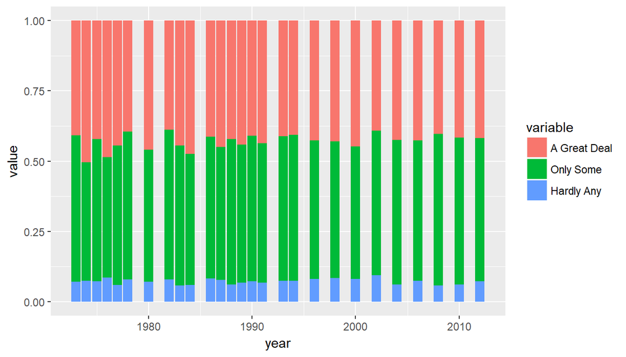

```r
#and now the graph

ggplot(m_sci_trust_year,aes(year,value,fill=variable))+
  geom_bar(position="fill",stat="identity")
```

We can plot the percent answers as lines.

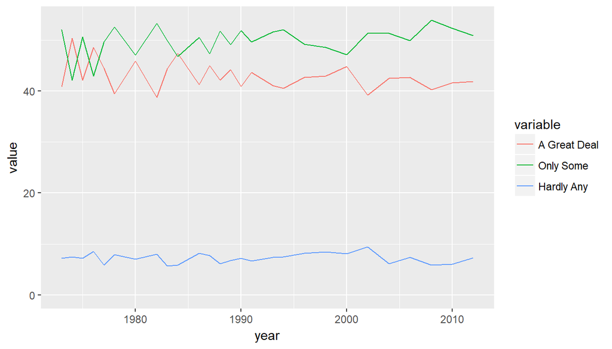

```r
ggplot(data=m_sci_trust_year,aes(x=year,y=value))+
  geom_line(aes(color=variable))+
  expand_limits(y=0)
```

The lines make it more clear that there is an ongoing “tradeoff” between “A Great Deal” and “Only Some” with “Hardly Any” somewhat more constant through time.

Since it looks moderately stable through time, let’s summarize our overall average answer percents throughout the dataset. Note that this is weighted by the number of responses across the data set.

```r
con_sci%>%
  summarize("A Great Deal"= 100*sum(agd)/n(),
            "Only Some"   = 100*sum(os) /n(),
            "Hardly Any"  = 100*sum(ha) /n())
```

```
##   A Great Deal Only Some Hardly Any
## 1      42.9454   49.7498     7.3048
```

That gives us a good enough understanding of the data to move into the analysis in a later section.

### Research Question 2: Overall, has there been a change in the yearly confidence that respondents have in Congress (conlegis) from when the question was first asked to 2012?

First, let’s create an object with just the lines with answers for the “conlegis” question.

```r
con_legis<-gss[c("year","conlegis")]
con_legis<-filter(con_legis,!is.na(conlegis))

head(con_legis)
```

```
##   year     conlegis
## 1 1973    Only Some
## 2 1973 A Great Deal
## 3 1973    Only Some
## 4 1973    Only Some
## 5 1973    Only Some
## 6 1973    Only Some
```

conlegis is a factor with three levels. The answers in conlegis can be (from the codebook)

A Great Deal

Only Some

Hardly Any

Next, let’s take the raw data and turn them into a yearly percent of respondents who have each level of confidence in Congress. To do this, we need to recode columns so that “A Great Deal” = 1 and anything else = 0, and so on with the other two.

```r
con_legis["agd"]<-ifelse(con_legis$conlegis=="A Great Deal",1,0)
con_legis["os"] <-ifelse(con_legis$conlegis=="Only Some"   ,1,0)
con_legis["ha"] <-ifelse(con_legis$conlegis=="Hardly Any"  ,1,0)

head(con_legis)
```

```
##   year     conlegis agd os ha
## 1 1973    Only Some   0  1  0
## 2 1973 A Great Deal   1  0  0
## 3 1973    Only Some   0  1  0
## 4 1973    Only Some   0  1  0
## 5 1973    Only Some   0  1  0
## 6 1973    Only Some   0  1  0
```

#### Summary Stats

Now we can make a vector with the yearly trust rate by summing each trust level column and dividing by the total number, then multiplying by 100 to make a percentage.

```r
legis_trust_year<-con_legis%>%
  group_by(year)%>%
  summarize("A Great Deal"= 100*sum(agd)/n(),
            "Only Some"   = 100*sum(os) /n(),
            "Hardly Any"  = 100*sum(ha) /n())

head(legis_trust_year)
```

```
## # A tibble: 6 x 4
##    year `A Great Deal` `Only Some` `Hardly Any`
##   <int>          <dbl>       <dbl>        <dbl>
## 1  1973       24.14266    60.56241     15.29492
## 2  1974       17.61838    60.86351     21.51811
## 3  1975       13.71191    60.38781     25.90028
## 4  1976       14.08935    59.72509     26.18557
## 5  1977       19.67546    62.67748     17.64706
## 6  1978       13.31981    65.11156     21.56863
```

Let’s make a stacked bar chart to see how things are changing during this time.

```r
#First we have to put the data into the long form for stacking

m_legis_trust_year<-melt(legis_trust_year,id.vars="year")

head(m_legis_trust_year)
```

```
##   year     variable    value
## 1 1973 A Great Deal 24.14266
## 2 1974 A Great Deal 17.61838
## 3 1975 A Great Deal 13.71191
## 4 1976 A Great Deal 14.08935
## 5 1977 A Great Deal 19.67546
## 6 1978 A Great Deal 13.31981
```

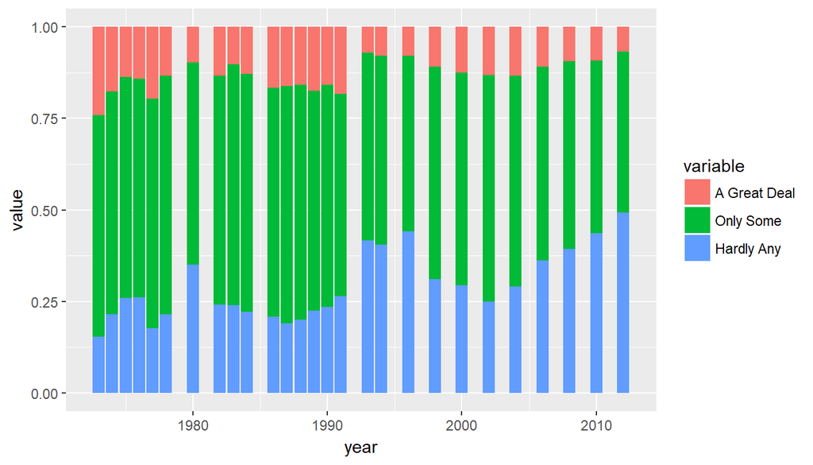

```r
#and now the graph

ggplot(m_legis_trust_year,aes(year,value,fill=variable))+
  geom_bar(position="fill",stat="identity")
```

We can plot the percent answers as lines.

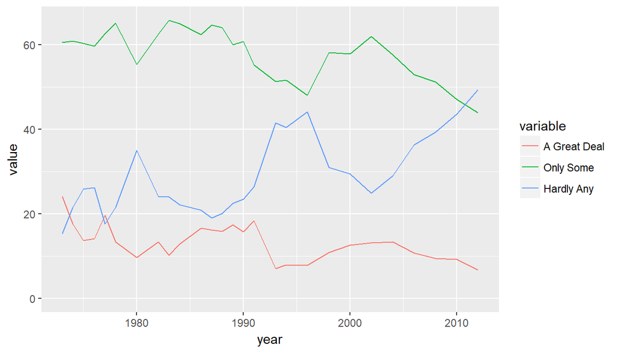

```r
ggplot(data=m_legis_trust_year,aes(x=year,y=value))+
  geom_line(aes(color=variable))+
  expand_limits(y=0)
```

Ouch, this shows quite a different story than the confidence in science. In the mid-1990s it looks like there was a big bump in “Hardly Any” along with drops in the other two categories. “A Great Deal” never recovers much from that. The “Only Some” category recovers slowly in the late 1990s coming from the “Hardly Any” category. Suddenly in the early 2000s that reverses with an ongoing increase in “Hardly Any”. By the end of the data set, the most common answer at almost 50% is “Hardly Any”. This is a brutal indictment of the confidence that people have in Congress.

It is not stable through time so an average won’t tell the whole story, but let’s summarize our overall average answer percents throughout the dataset to prepare for the analysis. Note that this is weighted by the number of responses across the data set.

```r
con_legis%>%
  summarize("A Great Deal"= 100*sum(agd)/n(),
            "Only Some"   = 100*sum(os) /n(),
            "Hardly Any"  = 100*sum(ha) /n())
```

```
##   A Great Deal Only Some Hardly Any
## 1     13.02441  57.84017   29.13543
```

That gives us a good enough understanding of the data to move into the analysis in a later section.

### Research Question 3: Overall, has there been a change in the yearly confidence that respondents have in the press from when the question was first asked to 2012?

First, let’s create an object with just the lines with answers for the “conpress” question.

```r
con_press<-gss[c("year","conpress")]
con_press<-filter(con_press,!is.na(conpress))

head(con_press)
```

```
##   year     conpress
## 1 1973    Only Some
## 2 1973    Only Some
## 3 1973    Only Some
## 4 1973    Only Some
## 5 1973   Hardly Any
## 6 1973 A Great Deal
```

conpress is a factor with three levels. The answers in conpress can be (from the codebook)

A Great Deal

Only Some

Hardly Any

Next, let’s take the raw data and turn them into a yearly percent of respondents who have each level of confidence in the press. To do this, we need to recode columns so that “A Great Deal” = 1 and anything else = 0, and so on with the other two.

```r
con_press["agd"]<-ifelse(con_press$conpress=="A Great Deal",1,0)
con_press["os"] <-ifelse(con_press$conpress=="Only Some",   1,0)
con_press["ha"] <-ifelse(con_press$conpress=="Hardly Any",  1,0)

head(con_press)
```

```
##   year     conpress agd os ha
## 1 1973    Only Some   0  1  0
## 2 1973    Only Some   0  1  0
## 3 1973    Only Some   0  1  0
## 4 1973    Only Some   0  1  0
## 5 1973   Hardly Any   0  0  1
## 6 1973 A Great Deal   1  0  0
```

#### Summary Stats

Now we can make a vector with the yearly trust rate by summing each trust level column and dividing by the total number, then multiplying by 100 to make a percentage.

We need to keep in mind that the percentages for the three answers are not independent - as a higher percentage choose one category, it is going to have to come from one of the other two categories.

```r
press_trust_year<-con_press%>%
  group_by(year)%>%
  summarize("A Great Deal"= 100*sum(agd)/n(),
            "Only Some"   = 100*sum(os) /n(),
            "Hardly Any"  = 100*sum(ha) /n())

head(press_trust_year)
```

```
## # A tibble: 6 x 4
##    year `A Great Deal` `Only Some` `Hardly Any`
##   <int>          <dbl>       <dbl>        <dbl>
## 1  1973       23.42586    61.67908     14.89506
## 2  1974       26.17908    56.11757     17.70335
## 3  1975       24.54924    57.07351     18.37725
## 4  1976       28.98154    53.04170     17.97676
## 5  1977       25.65305    58.53985     15.80710
## 6  1978       20.45303    59.49367     20.05330
```

Let’s make a stacked bar chart to see how things are changing during this time.

```r
#First we have to put the data into the long form for stacking

m_press_trust_year<-melt(press_trust_year,id.vars="year")

head(m_press_trust_year)
```

```
##   year     variable    value
## 1 1973 A Great Deal 23.42586
## 2 1974 A Great Deal 26.17908
## 3 1975 A Great Deal 24.54924
## 4 1976 A Great Deal 28.98154
## 5 1977 A Great Deal 25.65305
## 6 1978 A Great Deal 20.45303
```

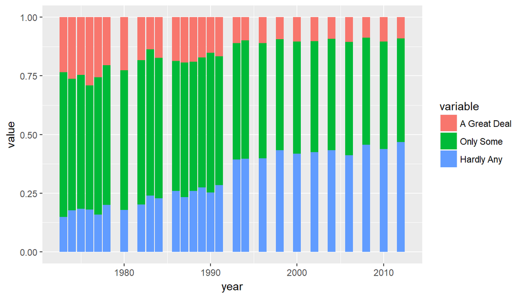

```r
#and now the graph

ggplot(m_press_trust_year,aes(year,value,fill=variable))+
  geom_bar(position="fill",stat="identity")
```

We can plot the percent answers as lines.

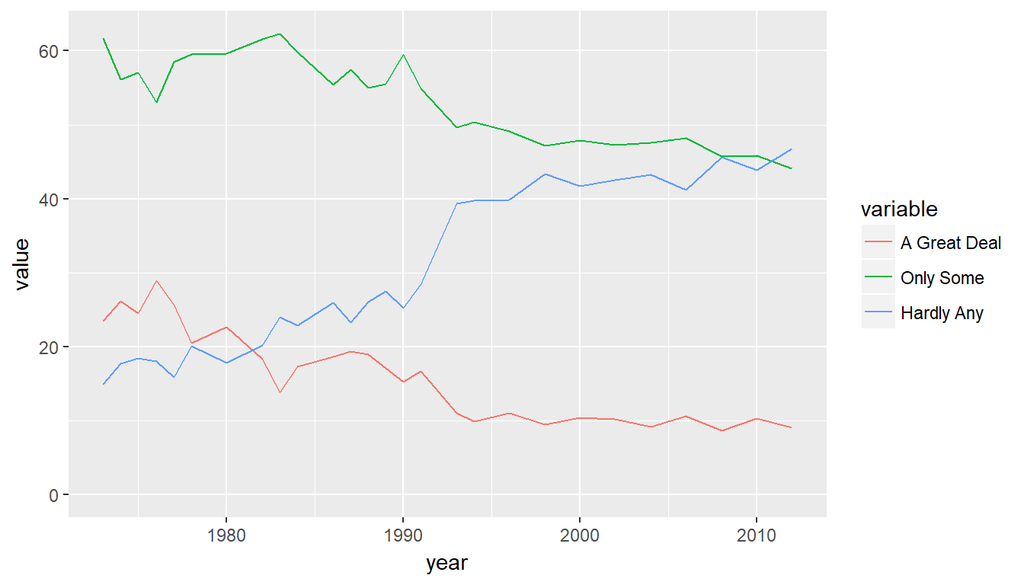

```r
ggplot(data=m_press_trust_year,aes(x=year,y=value))+
  geom_line(aes(color=variable))+
  expand_limits(y=0)
```

This also shows what looks like a decrease in public confidence in the press.

In the beginning we see that “Only Some” is fairly constant but that “A Great Deal” is decreasing as “Hardly Any” is increasing, perhaps indicating an across-the-board decrease in confidence in the press. Staring around 1990 though, we see a steep increase in the “Hardly Any” column at the expense of both the “A Great Deal” and “Only Some”. This stabilizes pretty quickly into a long-term increase in “Hardly Any” with a long-term decrease in the other two categories. Sadly, “Hardly Any” looks to be becoming the most popular choice.

It is not stable through time so an average won’t tell the whole story, but let’s summarize our overall average answer percents throughout the dataset to prepare for the analysis. Note that this is weighted by the number of responses across the data set.

```r
con_press%>%
  summarize("A Great Deal"= 100*sum(agd)/n(),
            "Only Some"   = 100*sum(os) /n(),
            "Hardly Any"  = 100*sum(ha) /n())
```

```
##   A Great Deal Only Some Hardly Any
## 1     16.15224  53.62819   30.21956
```

That gives us a good enough understanding of the data to move into the analysis in a later section.

## Part 4: Inference

There seems to be enough going on to explore with some actual analysis. Since the research question about confidence in science shows little change over the years, let’s focus on one of the others. Confidence in Congress showed a pretty dramatic graph, so let’s apply some statistical rigor to it.

In service to our **RQ#2: Overall, has there been a change in the yearly confidence that respondents have in Congress from when the question was first asked to 2012?** Let’s just focus on the probability of selecting “A Great Deal” as the answer.

### State hypotheses

We are interested in any change, up or down, from the original data collection, so we are looking at a non-directional **hypothesis test**:

H<sub>0</sub>: μ<sub>AGD 1973</sub> = μ<sub>AGD 2012</sub>  
H<sub>A</sub>: μ<sub>AGD 1973</sub> ≠ μ<sub>AGD 2012</sub>

### Check conditions

The data are 0s and 1s for each possible answer, 0 indicating that respondent did not select that answer and 1 indicating that they did. Therefore, the average of each column is the sample average proportion.

We can use the assumption that proportion data follow a reasonably normal distribution if np and nq are above 5. **Both years easily meet this criterion and therefore using a normal-based approach is justified.**. However, we don’t expect the graphs being generated by default to be particularly helpful for categorical data, so we should generate a means plot for the proportions with confidence intervals.

Since the respondents are separated in time (1973 to 2012) and are from different samples, it seems reasonable to conclude that the **data are independent**.

Although the t-test nominally requires equal variances, we also know that it is very robust to unequal variances with large sample sizes and pooled variances estimates, so **we are allowed to use the t-test with eual or unequal variances**. We will be checking with confidence intervals as well.

### State the method(s) to be used and why and how

Since we can reasonably use normal techniques, we can use the **t-test and generate confidence intervals**.

### Perform inference

```r
#Step 1: create a new data frame with responses from the first year (1973) and 2012

conlegis_inf<-con_legis%>%
  filter(year==1973 | year==2012)

head(conlegis_inf)
```

```
##   year     conlegis agd os ha
## 1 1973    Only Some   0  1  0
## 2 1973 A Great Deal   1  0  0
## 3 1973    Only Some   0  1  0
## 4 1973    Only Some   0  1  0
## 5 1973    Only Some   0  1  0
## 6 1973    Only Some   0  1  0
```

```r
#Now we can use the inference function. We will do the t-test first, then generate confidence intervals

inference(y=agd, x=as.factor(year), data=conlegis_inf, statistic="mean",type="ht",null=0, alternative="twosided",method="theoretical")
```

```
## Response variable: numerical
## Explanatory variable: categorical (2 levels)
## n_1973 = 1458, y_bar_1973 = 0.2414, s_1973 = 0.4281
## n_2012 = 1295, y_bar_2012 = 0.0672, s_2012 = 0.2504
## H0: mu_1973 =  mu_2012
## HA: mu_1973 != mu_2012
## t = 13.2047, df = 1294
## p_value = < 0.0001
```

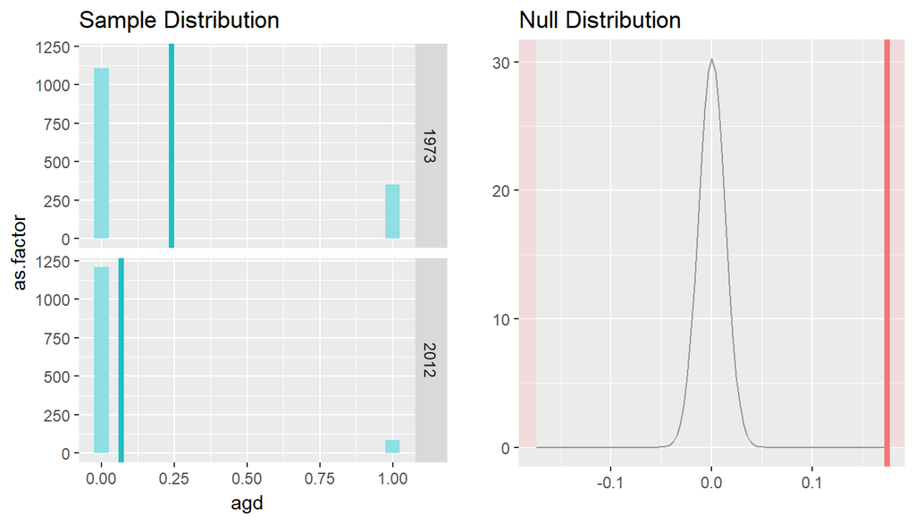

```r
inference(y=agd, x=as.factor(year), data=conlegis_inf,
          statistic="mean",type="ci",method="theoretical")
```

```
## Response variable: numerical, Explanatory variable: categorical (2 levels)
## n_1973 = 1458, y_bar_1973 = 0.2414, s_1973 = 0.4281
## n_2012 = 1295, y_bar_2012 = 0.0672, s_2012 = 0.2504
## 95% CI (1973 - 2012): (0.1484 , 0.2001)
```

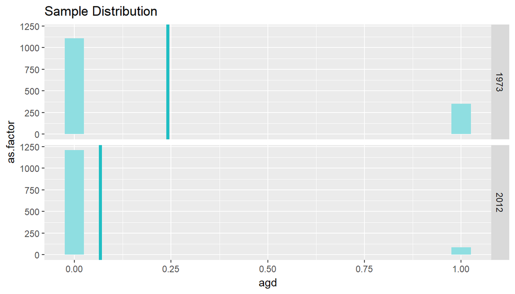

```r
#That gets us the means and standard deviations,
#but the graphs are not very helpful for binomial data.
#Let's plot a mean plot with error bars for each
#based on the confidence interval from the standard
#deviation within each year.

#Generate the dataframe for the graph from the output above

agd_year   <-c(1973,2012)
agd_mean   <-c(0.2414,0.0672)
agd_sd     <-c(0.4281,0.2504)
agd_n      <-c(1458,1295)
graph_data <-data.frame(agd_year,agd_mean,agd_sd,agd_n)

#and now for the 95% CI graph. Recall that the confidence interval is going to be:
```

$$\bar{x} \pm z^\star \frac{s}{\sqrt{n}}$$
where *z** is the z score for the required α/2 and *n*is the sample size for each.

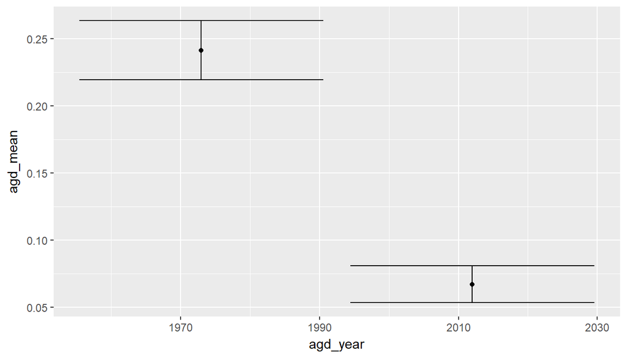

```r
#For a 95% confidence interval
z_star<-qnorm(0.975)

ggplot(graph_data,aes(x=agd_year,y=agd_mean))+
  geom_errorbar(aes(ymin=agd_mean-z_star*agd_sd/sqrt(agd_n),
                    ymax=agd_mean+z_star*agd_sd/sqrt(agd_n)))+
  geom_point()
```

### Interpret results

The t-test seems pretty definitive - with a **p-value of < 0.0001**. Since this is the probability of getting the mean difference that we say **if** there was in fact no difference, we are going to reject the null hypothesis and conclude that there has been a significant change in the percent of respondents saying that they had “A Great Deal” of confidence in Congress from 1973 to 2012. **Further support** is provided by examining the confidence interval of the difference of the mean proportions and finding that it does not include zero. Additionally, looking at the means plot above and seeing that the 95% confidence intervals of the means don’t overlap also supports the conclusion that we have reason to believe they are different.

### Shortcomings of the study

We do have some caveats about these results. Since the data for the project were extracted from the actual data set, some variables which could be used to control for various methodological changes are missing. It is not anticipated that this would change the conclusions however.

### Further research

I feel these questions need to be answered rather urgently.